# McDonald's Assignment

### Inference

# Q4 - Which category contributes to the maximum % of Cholesterol in a diet (% daily value)?

```python
a = pd.pivot_table(df,'Cholesterol (% Daily Value)', index= ['Category'])
a.sort_values(('Cholesterol (% Daily Value)'), ascending= False).reset_index()
```

|  | Category | Cholesterol (% Daily Value) |
| --- | --- | --- |
| 0 | Breakfast | 50.952381 |
| 1 | Beef & Pork | 28.933333 |
| 2 | Chicken & Fish | 25.222222 |
| 3 | Salads | 17.333333 |
| 4 | Smoothies & Shakes | 14.714286 |
| 5 | Coffee & Tea | 9.378947 |
| 6 | Snacks & Sides | 6.230769 |
| 7 | Desserts | 4.857143 |
| 8 | Beverages | 0.185185 |

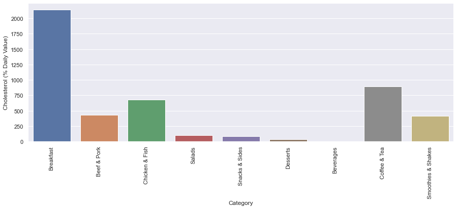

```python
plt.figure(figsize=(15,5))
sns.barplot(x='Category', y='Cholesterol (% Daily Value)', data=df, ci=None, estimator=np.sum);
plt.xticks(rotation=90)
plt.show()
```

### Inference

- Breakfast category contributes to the maximum % of of Cholesterol in a diet(% daily value)
- The above table is sorted and arranged the Categories from the High to Low values based on the Cholesterol(% Daily Value)

# Q5 - Which item contributes maximum to the Sodium intake?

```python
b = pd.pivot_table(df,'Sodium', index= ['Item'])
b.sort_values(('Sodium'), ascending= False).reset_index().head()
```

|  | Item | Sodium |
| --- | --- | --- |
| 0 | Chicken McNuggets (40 piece) | 3600 |
| 1 | Big Breakfast with Hotcakes and Egg Whites (La... | 2290 |
| 2 | Big Breakfast with Hotcakes (Large Biscuit) | 2260 |
| 3 | Big Breakfast with Hotcakes and Egg Whites (Re... | 2170 |
| 4 | Big Breakfast with Hotcakes (Regular Biscuit) | 2150 |

# Inference

The Item with maximum Sodium content is Chicken McNuggets (40 piece)

# Q6 - Which 4 food items contain the most amount of Saturated Fat?

```python
c= pd.pivot_table(df,'Saturated Fat', index= ['Item'])
c.sort_values(('Saturated Fat'), ascending= False).reset_index().head(10)
```

|  | Item | Saturated Fat |
| --- | --- | --- |
| 0 | McFlurry with M&M’s Candies (Medium) | 20.0 |
| 1 | Big Breakfast with Hotcakes (Large Biscuit) | 20.0 |
| 2 | Chicken McNuggets (40 piece) | 20.0 |
| 3 | Frappé Chocolate Chip (Large) | 20.0 |
| 4 | Double Quarter Pounder with Cheese | 19.0 |
| 5 | Big Breakfast with Hotcakes (Regular Biscuit) | 19.0 |
| 6 | Big Breakfast (Large Biscuit) | 18.0 |
| 7 | Frappé Mocha (Large) | 17.0 |
| 8 | Frappé Chocolate Chip (Medium) | 17.0 |
| 9 | Big Breakfast (Regular Biscuit) | 17.0 |

# Inference

The Items which contain the maximun amount of Saturated Fat are as follows

- McFlurry with M&M’s Candies (Medium)
- Big Breakfast with Hotcakes (Large Biscuit)
- Chicken McNuggets (40 piece)
- Frappé Chocolate Chip (Large)